# Home assignment 1

Novin Shahroudi

# Exercise 1 - Principle Component Analysis

```r
sprintf("total variation: %f", sum(diag(S)))
```

```
[1] "total variation: 292.900000"
```

Correlation matrix can be calculated using the following formula:
$$R = S_d^{-1/2}SS_d^{-1/2}$$
Where $R$ is the obtained correlation matrix, $S$ is the covariance matrix and $S_d$ is the diagonal matrix of the covariance matrix diagonal.

The above formula corresponds to the following equation:
$$\rho_ = \frac{\sigma_{ij}}{\sqrt{\sigma_{ii}}\sqrt{\sigma_{jj}}}$$

```r
(R = S_d %*% S %*% S_d)
```

```
          [,1]      [,2]      [,3]      [,4]      [,5]
[1,] 1.0000000 0.6133358 0.7572201 0.5755426 0.4126499
[2,] 0.6133358 1.0000000 0.5463275 0.7489878 0.5482850
[3,] 0.7572201 0.5463275 1.0000000 0.6057556 0.6914901
[4,] 0.5755426 0.7489878 0.6057556 1.0000000 0.5243460
[5,] 0.4126499 0.5482850 0.6914901 0.5243460 1.0000000
```

## a) ‘probe word’ data

**PCA with S**: Principle components correspond to the eigen vectors. In order to obtain those we use R built-in function `eigen` on the covariance matrix $S$.

|  | PC1 | PC2 | PC3 | PC4 | PC5 |
| --- | --- | --- | --- | --- | --- |
| vector_cmp1 | -0.47 | 0.59 | 0.40 | 0.23 | 0.47 |
| vector_cmp2 | -0.39 | 0.10 | -0.46 | 0.66 | -0.45 |
| vector_cmp3 | -0.49 | -0.08 | 0.48 | -0.37 | -0.62 |
| vector_cmp4 | -0.47 | 0.11 | -0.62 | -0.58 | 0.21 |
| vector_cmp5 | -0.41 | -0.79 | 0.11 | 0.21 | 0.39 |
| variance | 200.36 | 36.09 | 34.05 | 15.02 | 7.38 |
| cumulative variance | 200.36 | 236.45 | 270.50 | 285.52 | 292.90 |
| cumulative variance in percentage | 68.40 | 80.73 | 92.35 | 97.48 | 100.00 |

Eigen vector, variance, cumulative variance and its percentage for each principle component reported in the table achieved from covariance matrix.

**PCA with R**:

```r
(V <- eigen(R)$vectors) # Eigen vectors
```

```
          [,1]       [,2]       [,3]       [,4]       [,5]
[1,] 0.4417930 -0.2052565  0.6766520  0.2147844  0.5086241
[2,] 0.4533185 -0.4262381 -0.3543178  0.6042313 -0.3495523
[3,] 0.4727613  0.3660142  0.3786029 -0.2555432 -0.6587017
[4,] 0.4538024 -0.3910314 -0.3339764 -0.7027525  0.1890938
[5,] 0.4121667  0.6995133 -0.4021450  0.1720718  0.3866140
```

Based on this and previous table We need to consider two principle components to explain 80% of the variance and three PCs for 90%. That can be observed from the cumulative variance of the obtained principle components.

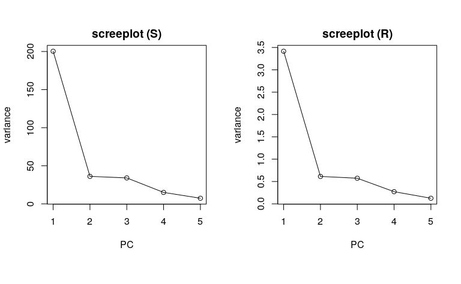

As a conclusion for our case since the input features are of same unit we can use covariance matrix. Also It is worthnoty that the outcome of using covariance and correlation matrix are almost the same! % TODO: why - is it because they are of same units?

The screeplot shows the elbow in the first 2 components.